# ElaboratoFinale

Francesco Gabellini

4/10/2020

Importo le librerie necessarie all’elaborazione dati

Importo i dati precedentemente salvati dallo script di ingestion

```r
df_temp1 <- read.csv("C:/Users/gabel/Desktop/Tesi/Script/BaseDati/03to0708.csv", comment.char="#")
df_temp2 <- read.csv("C:/Users/gabel/Desktop/Tesi/Script/BaseDati/10to1408.csv", comment.char="#")
df_temp3 <- read.csv("C:/Users/gabel/Desktop/Tesi/Script/BaseDati/17to2108.csv", comment.char="#")
df_temp4 <- read.csv("C:/Users/gabel/Desktop/Tesi/Script/BaseDati/24to2808.csv", comment.char="#")
df_temp5 <- read.csv("C:/Users/gabel/Desktop/Tesi/Script/BaseDati/31to0409.csv", comment.char="#")
df_temp6 <- read.csv("C:/Users/gabel/Desktop/Tesi/Script/BaseDati/07to1109.csv", comment.char="#")
df_temp7 <- read.csv("C:/Users/gabel/Desktop/Tesi/Script/BaseDati/1109.csv", comment.char="#")
df_temp8 <- read.csv("C:/Users/gabel/Desktop/Tesi/Script/BaseDati/14to1809.csv", comment.char="#")
df_temp9 <- read.csv("C:/Users/gabel/Desktop/Tesi/Script/BaseDati/21to2609.csv", comment.char="#")
df_temp10 <- read.csv("C:/Users/gabel/Desktop/Tesi/Script/BaseDati/28to0310.csv", comment.char="#")

df_temp <- rbind.data.frame(df_temp1,df_temp2,df_temp3,df_temp4,df_temp5,df_temp6,df_temp7,df_temp8,df_temp9,df_temp10 )
rm(df_temp1,df_temp2,df_temp3,df_temp4,df_temp5,df_temp6,df_temp7,df_temp8,df_temp9,df_temp10 )
```

Seleziono solo il testo e il timestamp del tweet

```r
df <- df_temp %>%
  dplyr::select(text,created) %>%
   mutate(timestamp = ymd_hms(created))
rm(df_temp)
```

Conteggio il numero di Tweet nel tempo

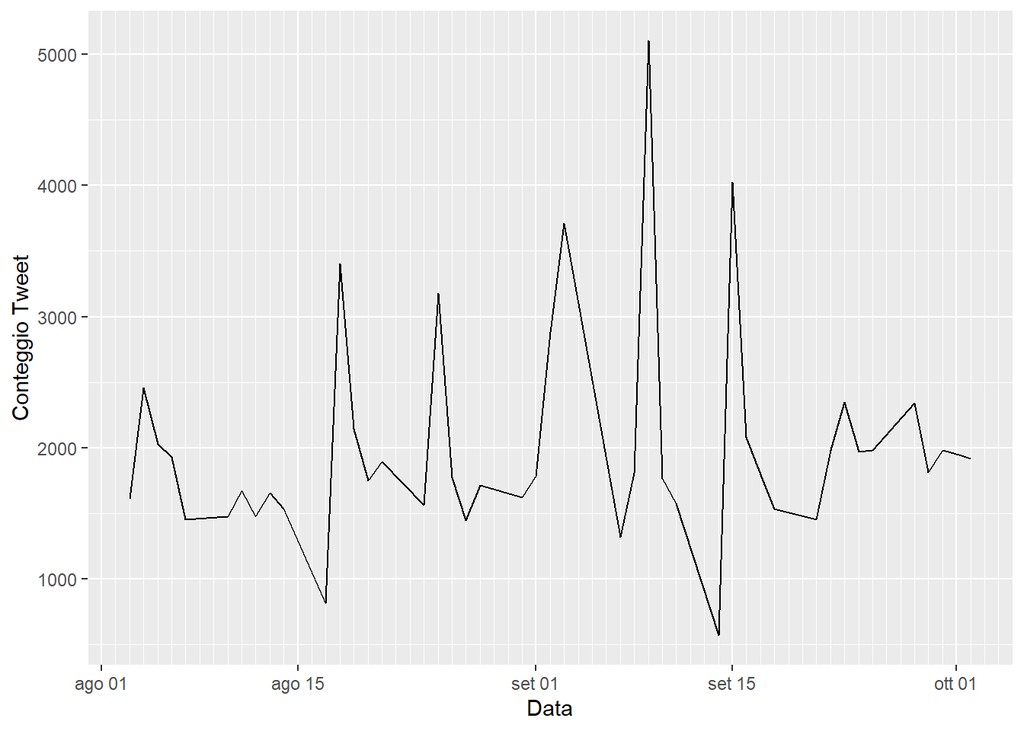

```r
df <- df %>% filter(timestamp <= as.Date("2020-10-03"))

df$timestamp=  as.Date(df$timestamp)

ggplot(df %>% count(timestamp), aes(x = timestamp, n)) +
  geom_line() +
  labs(y = "Conteggio Tweet",x="Data")+
  scale_x_date(date_minor_breaks = "1 day")
```

Elimino dal testo: - Stopwords - Numeri - Hashtag o altri caratteri speciali - Le keyword usate per la ricerca

```r
stopwords <- as.data.frame(stopwords(language = "it",source = "nltk"))
colnames(stopwords) <- "word"

unnested <- df %>%
unnest_tokens(word, text, token = "tweets")
```

```
## Using `to_lower = TRUE` with `token = 'tweets'` may not preserve URLs.
```

```r
tidy_tweets <- unnested %>%
  anti_join(stopwords) %>%
  filter(nchar(word)>2)%>%
  filter(!str_detect(word,pattern="0"))%>%
  filter(!str_detect(word,pattern="1"))%>%
  filter(!str_detect(word,pattern="2"))%>%
  filter(!str_detect(word,pattern="3"))%>%
  filter(!str_detect(word,pattern="4"))%>%
  filter(!str_detect(word,pattern="5"))%>%
  filter(!str_detect(word,pattern="6"))%>%
  filter(!str_detect(word,pattern="7"))%>%
  filter(!str_detect(word,pattern="8"))%>%
  filter(!str_detect(word,pattern="9"))%>%
  filter(!str_detect(word,pattern=","))%>%
  filter(!str_detect(word,pattern="'"))%>%
  filter(!str_detect(word,pattern="rt"))%>%
  filter(!str_detect(word,pattern="#\\S+"))%>%
  filter(!str_detect(word,pattern="@\\S+"))%>%
  filter(!str_detect(word,pattern="https:\\S+"))%>%
  filter(!str_detect(word,pattern="punti"))%>%
  filter(!str_detect(word,pattern="apre"))%>%
  filter(!str_detect(word,pattern="chiude"))%>%
  filter(!str_detect(word,pattern="=gt"))%>%
  filter(!str_detect(word,pattern="chiusura"))%>%
  filter(!str_detect(word,pattern="ftse"))%>%
  filter(!str_detect(word,pattern="FtseMib"))%>%
  filter(!str_detect(word,pattern="BorsaItaliana"))%>%
  filter(!str_detect(word,pattern="a2a"))%>%
  filter(!str_detect(word,pattern="atlantia"))%>%
  filter(!str_detect(word,pattern="azimut"))%>%
  filter(!str_detect(word,pattern="mediolanum"))%>%
  filter(!str_detect(word,pattern="bpm"))%>%
  filter(!str_detect(word,pattern="bper"))%>%
  filter(!str_detect(word,pattern="campari"))%>%
  filter(!str_detect(word,pattern="cnh"))%>%
  filter(!str_detect(word,pattern="enel"))%>%
  filter(!str_detect(word,pattern="eni"))%>%
  filter(!str_detect(word,pattern="exor"))%>%
  filter(!str_detect(word,pattern="ferrari"))%>%
  filter(!str_detect(word,pattern="exor"))%>%
  filter(!str_detect(word,pattern="fiat"))%>%
  filter(!str_detect(word,pattern="finecobank"))%>%
  filter(!str_detect(word,pattern="generali"))%>%
  filter(!str_detect(word,pattern="hera"))%>%
  filter(!str_detect(word,pattern="leonardo"))%>%
  filter(!str_detect(word,pattern="intesa"))%>%
  filter(!str_detect(word,pattern="mediobanca"))%>%
  filter(!str_detect(word,pattern="moncler"))%>%
  filter(!str_detect(word,pattern="pirelli"))%>%
  filter(!str_detect(word,pattern="poste"))%>%
  filter(!str_detect(word,pattern="saipem"))%>%
  filter(!str_detect(word,pattern="snam"))%>%
  filter(!str_detect(word,pattern="telecom"))%>%
  filter(!str_detect(word,pattern="unicredit"))%>%
  filter(!str_detect(word,pattern="unipol"))%>%
  filter(!str_detect(word,pattern="#\\S+"))%>%
  mutate(date = as.Date(timestamp))
tidy_tweets$word <- gsub("[[:punct:]]", "", tidy_tweets$word )
rm(unnested)
rm(stopwords)
```

Import vocabolario per Sentiment Analysis: OpeNER Sentiment Lexicon Italian - LMF

```r
PositiveNegative <- read.csv("C:/Users/gabel/Desktop/Tesi/Script/PositiveNegative.csv", sep=";")
Ita_Sent <- PositiveNegative %>% select(Word, Sentiment,Score)
names(Ita_Sent) <- c('word','sentiment',"Score")
rm(PositiveNegative)
```

Associo il sentimet alle parole precedentemente pulite

```r
tidy_sentiment <-  tidy_tweets %>%
  inner_join(Ita_Sent) %>%
 filter( sentiment == "negative" | sentiment == "positive")%>%
   mutate(score = ifelse(sentiment== "negative",-Score,Score))
```

Mostro le parole più frequenti per sentiment

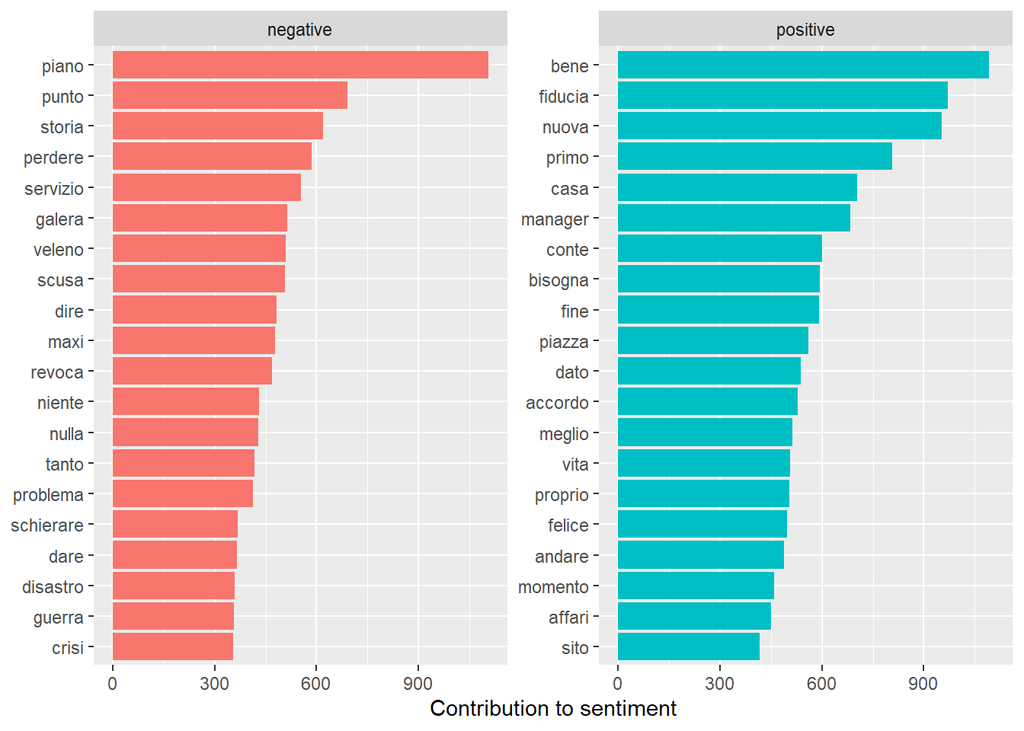

```r
Sentiment_count <- tidy_sentiment  %>%
  count(word, sentiment, sort = TRUE) %>%
  ungroup()

Sentiment_count %>%
  group_by(sentiment) %>%
  top_n(20) %>%
  ungroup() %>%
  mutate(word = reorder(word, n)) %>%
  ggplot(aes(word, n, fill = sentiment)) +
  geom_col(show.legend = FALSE) +
  facet_wrap(~sentiment, scales = "free_y") +
  labs(y = "Contribution to sentiment",
       x = NULL) +
  coord_flip()
```

```r
rm(Sentiment_count)
```

Creo i diversi score del sentiment:

Approccio differenze tra polarità :

```r
tidy_sentiment <-  tidy_tweets %>%
  inner_join(Ita_Sent) %>%
 filter( sentiment == "negative" | sentiment == "positive")%>%
   mutate(SentimentScore = ifelse(sentiment== "negative",-Score,Score))
```

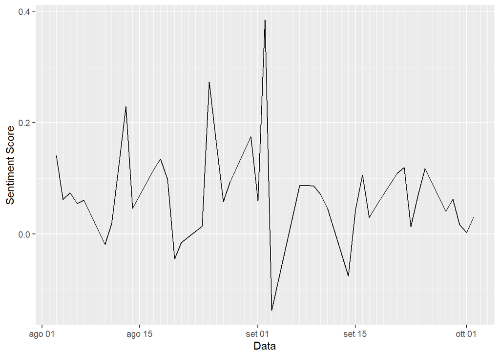

```r
Sentiment_Score <- tidy_sentiment  %>%
  group_by(date)%>%
  summarise(DailyScore = sum(SentimentScore)/n())

ggplot(Sentiment_Score, aes(x = date,y=DailyScore)) +
  geom_line() +
  labs(y = "Sentiment Score",x="Data")+
  scale_x_date(date_minor_breaks = "1 day")
```

Smoothing della serie

Moving Avarage settimanale appiattisce troppo la serie, provo approccio con decay esponeziale per creare una serie piu reattiva.

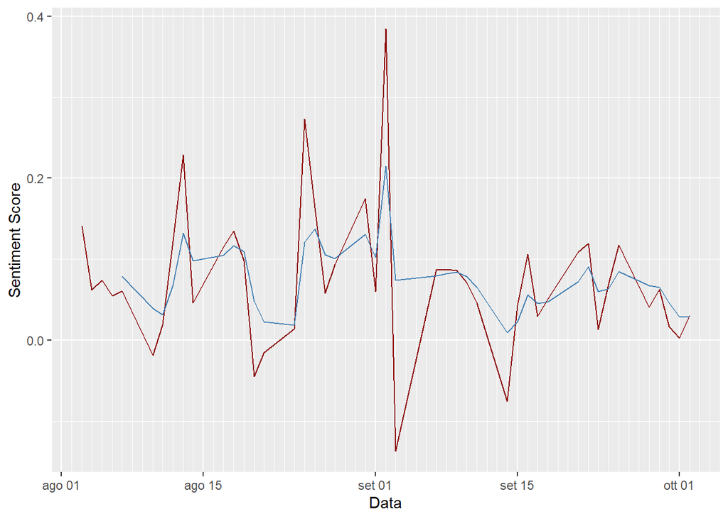

```r
smooth <- EMA(Sentiment_Score$DailyScore,n=5,ratio=0.4)
Sentiment_Score$Smooth <- smooth
ggplot(Sentiment_Score, aes(x = date)) +
  geom_line(aes(y = DailyScore), color = "darkred") +
  geom_line(aes(y = Smooth), color="steelblue") +
  labs(y = "Sentiment Score",x="Data")+
  scale_x_date(date_minor_breaks = "1 day")
```

Estraggo i prezzi azionari e creo la realized volatility nello stesso orizzonte temporale dei tweet

```r
prices <- read_excel("FTSE.xlsx", col_types = c("date", "numeric","numeric","numeric","numeric"))
Indice <- prices %>%  select (date)
Indice$vola <- volatility(prices[,2:5],n = 5, calc = "garman.klass", N = 250, mean0 = TRUE)
Indice$date =  as.Date(Indice$date)
```

Visualizzo la volatilità

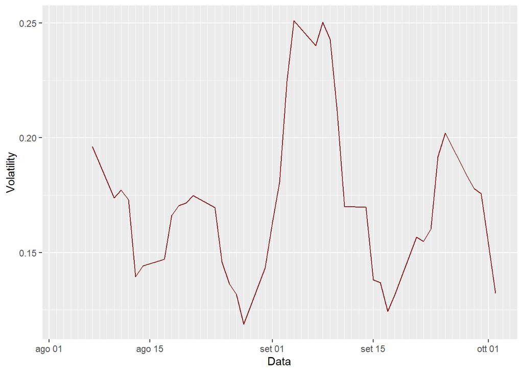

```r
ggplot(Indice, aes(x = date)) +
  geom_line(aes(y = vola), color = "darkred") +
  labs(y = "Volatility",x="Data")+
  scale_x_date(date_minor_breaks = "1 day")
```

Unisco dati relativi allo score all’indice

```r
# Indice$ScaleIndice <- scale(Indice$returns)
Sentiment_Score$Scale <- Sentiment_Score$Smooth

df_Score <-  Indice %>%
  inner_join(Sentiment_Score) %>%
  select(date,vola,Scale)
colnames(df_Score) <- c("date","Indice","Sentiment")
df_Score <- df_Score[!is.na(df_Score$Indice), ]
```

Granger Test

```r
datalist = list()

for (i in 1:5) {
    dat <- grangertest(Indice ~ Sentiment, order = i, data = df_Score )
    dat$lag <- i
    datalist[[i]] <- dat
}

resultsSentiment1 = na.omit(do.call(rbind, datalist))
resultsSentiment1
```

```
## Granger causality test
##
## Model 1: Indice ~ Lags(Indice, 1:1) + Lags(Sentiment, 1:1)
## Model 2: Indice ~ Lags(Indice, 1:1)
##    Res.Df Df      F   Pr(>F) lag
## 2      37 -1 8.0437 0.007449   1
## 21     35 -2 3.3924 0.045726   2
## 22     33 -3 3.6179 0.024282   3
## 23     31 -4 2.9061 0.040288   4
## 24     29 -5 1.9036 0.131103   5
```

Il lag 1 è il piu singnificativo

```r
grangertest(Indice ~ Sentiment, order = 1, data = df_Score )
```

```
## Granger causality test
##
## Model 1: Indice ~ Lags(Indice, 1:1) + Lags(Sentiment, 1:1)
## Model 2: Indice ~ Lags(Indice, 1:1)
##   Res.Df Df      F   Pr(>F)
## 1     36
## 2     37 -1 8.0437 0.007449 **
## ---
## Signif. codes:  0 '***' 0.001 '**' 0.01 '*' 0.05 '.' 0.1 ' ' 1
```

Sentiment Più complessa:

Importo i sentiment dal pacchetto

```r
nrc <- read_excel("nrc.xlsx")

tidy_sentiment2 <-  tidy_tweets %>%
  inner_join(nrc)
```

Ne calcolo i diversi valori giornalieri

```r
Sentiment_Score2 <- tidy_sentiment2  %>%
  group_by(date)%>%
  summarise(Anger = sum(Anger)/n(),Anticipation = sum(Anticipation)/n(),Disgust = sum(Disgust)/n(),Fear = sum(Fear)/n(),Joy = sum(Joy)/n(),Sadness = sum(Sadness)/n(),Surprise = sum(Surprise)/n(),Trust = sum(Trust)/n())



Sentiment_Score2 <- cbind.data.frame(Sentiment_Score2$date,Sentiment_Score2[,2:9])
names(Sentiment_Score2)[1] <- "date"
rm(tidy_sentiment2)
```

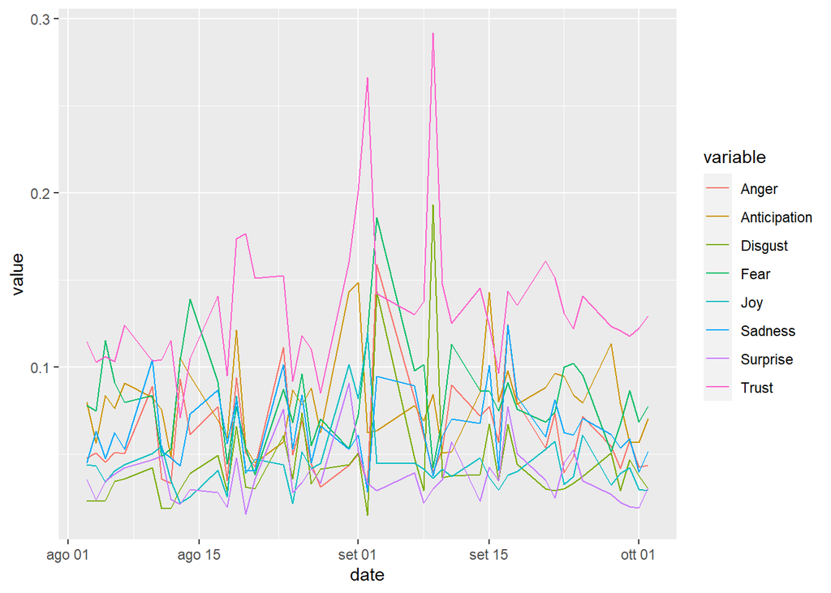

```r
dataplot <- melt(Sentiment_Score2, id="date")  # convert to long format

ggplot(data=dataplot,
       aes(x=date, y=value, colour=variable)) +
       geom_line()
```

Visualizzo le diverse correlazioni tra i vari sentiment

```r
cor(na.omit(Sentiment_Score2[,2:8]))
```

```
##                    Anger Anticipation     Disgust         Fear         Joy
## Anger         1.00000000   0.08877324  0.42380958  0.590339802 -0.04715047
## Anticipation  0.08877324   1.00000000  0.13691879 -0.026491776  0.29814375
## Disgust       0.42380958   0.13691879  1.00000000  0.165385862 -0.03587933
## Fear          0.59033980  -0.02649178  0.16538586  1.000000000  0.01889715
## Joy          -0.04715047   0.29814375 -0.03587933  0.018897151  1.00000000
## Sadness       0.76128514   0.20073653  0.27045795  0.369143190 -0.03666265
## Surprise      0.27780066   0.39459181  0.08607005  0.009581816  0.37849325
##                  Sadness    Surprise
## Anger         0.76128514 0.277800664
## Anticipation  0.20073653 0.394591807
## Disgust       0.27045795 0.086070046
## Fear          0.36914319 0.009581816
## Joy          -0.03666265 0.378493250
## Sadness       1.00000000 0.410105696
## Surprise      0.41010570 1.000000000
```

Unisco dati relativi all indice di borsa e applico lo stesso smoothing applicato alla serie di sentiment precedente

```r
df_Score2 <-  Indice %>%
  inner_join(Sentiment_Score2) %>%
  select(date,vola,Anger,Anticipation,Disgust,Fear,Joy,Sadness,Surprise,Trust)
#df_Score2 = df_Score2[-1,]
df_Score2$Anger <- EMA(df_Score2$Anger,n=5,ratio=0.4)
df_Score2$Anticipation <- EMA(df_Score2$Anticipation,n=5,ratio=0.4)
df_Score2$Disgust <- EMA(df_Score2$Disgust,n=5,ratio=0.4)
df_Score2$Fear <- EMA(df_Score2$Fear,n=5,ratio=0.4)
df_Score2$Joy <- EMA(df_Score2$Joy,n=5,ratio=0.4)
df_Score2$Sadness <- EMA(df_Score2$Sadness,n=5,ratio=0.4)
df_Score2$Surprise <- EMA(df_Score2$Surprise,n=5,ratio=0.4)
df_Score2$Trust <- EMA(df_Score2$Trust,n=5,ratio=0.4)
```

Per ogni sentiment calcolo i diversi ritardi ,e il test di granger.

Anger

```r
datalist = list()

for (i in 1:5) {
    dat <- grangertest(vola ~ Anger, order = i, data = df_Score2 )
    dat$lag <- i
    datalist[[i]] <- dat
}

resultsanger = na.omit(do.call(rbind, datalist))
resultsanger
```

```
## Granger causality test
##
## Model 1: vola ~ Lags(vola, 1:1) + Lags(Anger, 1:1)
## Model 2: vola ~ Lags(vola, 1:1)
##    Res.Df Df      F  Pr(>F) lag
## 2      37 -1 0.2143 0.64619   1
## 21     35 -2 0.2152 0.80750   2
## 22     33 -3 0.6936 0.56316   3
## 23     31 -4 0.6831 0.60979   4
## 24     29 -5 0.9087 0.49185   5
```

Anticipation

```r
datalist = list()

for (i in 1:5) {
    dat <- grangertest(vola ~ Anticipation, order = i, data = df_Score2 )
    dat$lag <- i
    datalist[[i]] <- dat
}

resultsAnticipation = na.omit(do.call(rbind, datalist))
resultsAnticipation
```

```
## Granger causality test
##
## Model 1: vola ~ Lags(vola, 1:1) + Lags(Anticipation, 1:1)
## Model 2: vola ~ Lags(vola, 1:1)
##    Res.Df Df       F  Pr(>F) lag
## 2      37 -1 12.8509 0.00099   1
## 21     35 -2  4.6067 0.01720   2
## 22     33 -3  2.3017 0.09725   3
## 23     31 -4  1.3578 0.27462   4
## 24     29 -5  0.8234 0.54531   5
```

Disgust

```r
datalist = list()

for (i in 1:5) {
    dat <- grangertest(vola ~ Disgust, order = i, data = df_Score2 )
    dat$lag <- i
    datalist[[i]] <- dat
}

resultsDisgust = na.omit(do.call(rbind, datalist))
resultsDisgust
```

```
## Granger causality test
##
## Model 1: vola ~ Lags(vola, 1:1) + Lags(Disgust, 1:1)
## Model 2: vola ~ Lags(vola, 1:1)
##    Res.Df Df      F  Pr(>F) lag
## 2      37 -1 0.4771 0.49416   1
## 21     35 -2 0.0477 0.95349   2
## 22     33 -3 0.3776 0.76983   3
## 23     31 -4 1.0366 0.40657   4
## 24     29 -5 0.8208 0.54698   5
```

Fear

```r
datalist = list()

for (i in 1:5) {
    dat <- grangertest(vola ~ Fear, order = i, data = df_Score2 )
    dat$lag <- i
    datalist[[i]] <- dat
}

resultsFear = na.omit(do.call(rbind, datalist))
resultsFear
```

```
## Granger causality test
##
## Model 1: vola ~ Lags(vola, 1:1) + Lags(Fear, 1:1)
## Model 2: vola ~ Lags(vola, 1:1)
##    Res.Df Df      F   Pr(>F) lag
## 2      37 -1 5.9631 0.019651   1
## 21     35 -2 2.5336 0.094710   2
## 22     33 -3 2.0597 0.126642   3
## 23     31 -4 2.7517 0.048568   4
## 24     29 -5 1.7982 0.151335   5
```

Joy

```r
datalist = list()

for (i in 1:5) {
    dat <- grangertest(vola ~ Joy, order = i, data = df_Score2 )
    dat$lag <- i
    datalist[[i]] <- dat
}

resultsJoy = na.omit(do.call(rbind, datalist))
resultsJoy
```

```
## Granger causality test
##
## Model 1: vola ~ Lags(vola, 1:1) + Lags(Joy, 1:1)
## Model 2: vola ~ Lags(vola, 1:1)
##    Res.Df Df       F   Pr(>F) lag
## 2      37 -1 16.9564 0.000213   1
## 21     35 -2  4.5719 0.017675   2
## 22     33 -3  2.8815 0.052202   3
## 23     31 -4  1.9915 0.124273   4
## 24     29 -5  1.7655 0.158229   5
```

Sadness

```r
datalist = list()

for (i in 1:5) {
    dat <- grangertest(vola ~ Sadness, order = i, data = df_Score2 )
    dat$lag <- i
    datalist[[i]] <- dat
}

resultsSadness = na.omit(do.call(rbind, datalist))
resultsSadness
```

```
## Granger causality test
##
## Model 1: vola ~ Lags(vola, 1:1) + Lags(Sadness, 1:1)
## Model 2: vola ~ Lags(vola, 1:1)
##    Res.Df Df      F  Pr(>F) lag
## 2      37 -1 1.1100 0.29909   1
## 21     35 -2 0.3999 0.67359   2
## 22     33 -3 0.8159 0.49523   3
## 23     31 -4 1.2509 0.31339   4
## 24     29 -5 0.8138 0.55155   5
```

Surprise

```r
datalist = list()

for (i in 1:5) {
    dat <- grangertest(vola ~ Surprise, order = i, data = df_Score2 )
    dat$lag <- i
    datalist[[i]] <- dat
}

resultsSurprise = na.omit(do.call(rbind, datalist))
resultsSurprise
```

```
## Granger causality test
##
## Model 1: vola ~ Lags(vola, 1:1) + Lags(Surprise, 1:1)
## Model 2: vola ~ Lags(vola, 1:1)
##    Res.Df Df      F  Pr(>F) lag
## 2      37 -1 5.5047 0.02459   1
## 21     35 -2 1.0894 0.34821   2
## 22     33 -3 1.2591 0.30609   3
## 23     31 -4 0.9075 0.47359   4
## 24     29 -5 1.9992 0.11512   5
```

Trust

```r
datalist = list()

for (i in 1:5) {
    dat <- grangertest(vola ~ Trust, order = i, data = df_Score2 )
    dat$lag <- i
    datalist[[i]] <- dat
}

resultsTrust = na.omit(do.call(rbind, datalist))
resultsTrust
```

```
## Granger causality test
##
## Model 1: vola ~ Lags(vola, 1:1) + Lags(Trust, 1:1)
## Model 2: vola ~ Lags(vola, 1:1)
##    Res.Df Df      F  Pr(>F) lag
## 2      37 -1 1.1873 0.28312   1
## 21     35 -2 0.4285 0.65504   2
## 22     33 -3 0.4950 0.68851   3
## 23     31 -4 1.2900 0.29865   4
## 24     29 -5 0.8019 0.55937   5
```

Ne testo la correlazione

```r
res1 <- cor.test(df_Score2$Anticipation, df_Score2$Joy,
                    method = "pearson")
res1
```

```
##
##  Pearson's product-moment correlation
##
## data:  df_Score2$Anticipation and df_Score2$Joy
## t = 2.7656, df = 38, p-value = 0.008721
## alternative hypothesis: true correlation is not equal to 0
## 95 percent confidence interval:
##  0.1121232 0.6393235
## sample estimates:
##       cor
## 0.4093355
```

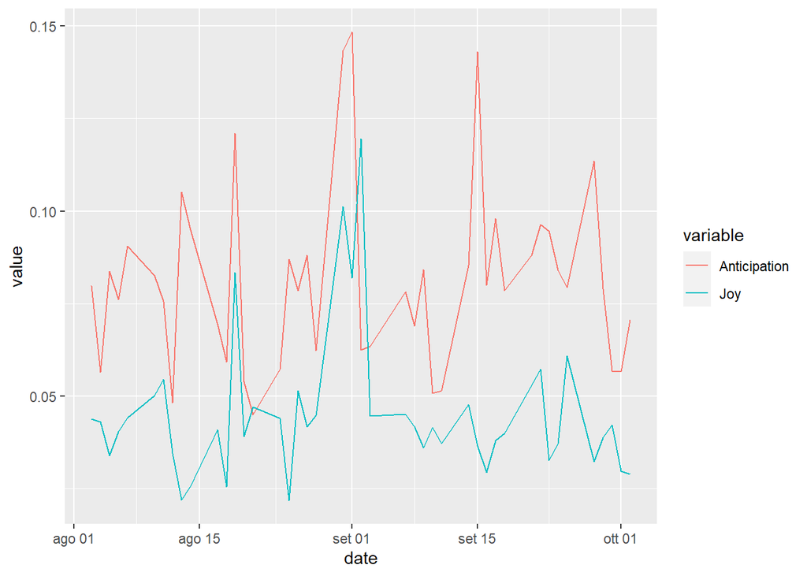

```r
dataplot <- melt(Sentiment_Score2 %>% select(date,Anticipation,Joy), id="date")  # convert to long format

ggplot(data=dataplot,
       aes(x=date, y=value, colour=variable)) +
       geom_line()
```

Approccio Econometrico:

train test

```r
totale <- cbind.data.frame(na.omit(
df_Score2 %>% select(date,Anticipation,Joy,vola))

                           ,df_Score$Sentiment)
colnames(totale) <- c("date","Anticipation","Joy","Vola","Sentiment")
totale <- totale %>%
  mutate(lagAnticipation =lag(Anticipation)) %>%
  mutate(lagJoy =lag(Joy)) %>%
  mutate(lagSentiment =lag(Sentiment))


#Separo gli ultimi 3 giorni per stima out of sample
train <- totale %>% slice(1:35)
test <- totale %>% slice(36:40)
```

Studio struttura Volatilità

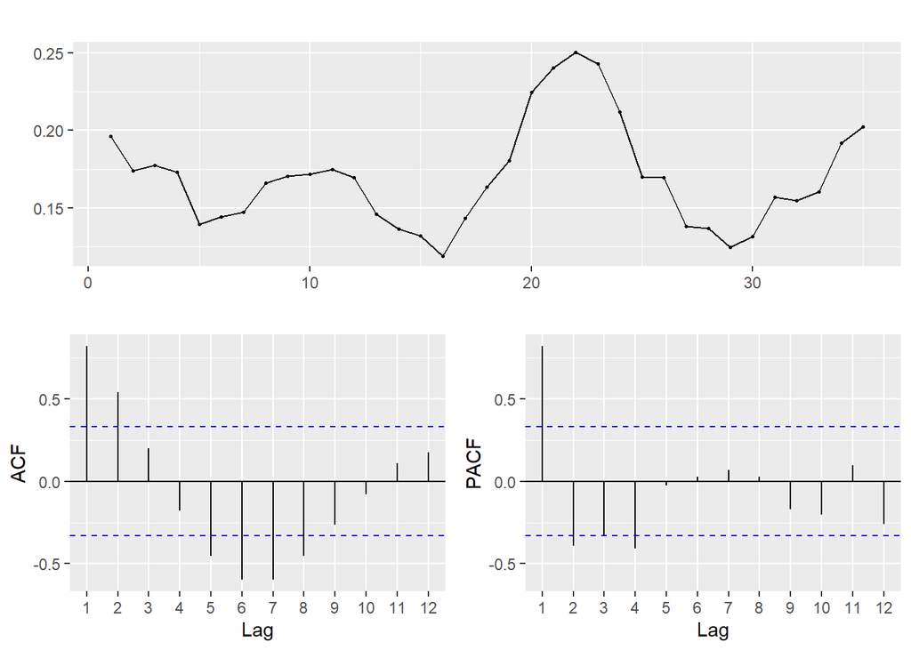

```r
#BasicArma=arima(train, order=c(1,0,1))
ggtsdisplay(train$Vola)
```

```r
fit1 <- Arima(train$Vola, order=c(2,0,1))
fit1
```

```
## Series: train$Vola
## ARIMA(2,0,1) with non-zero mean
##
## Coefficients:
##          ar1      ar2      ma1    mean
##       1.7235  -0.8874  -0.7629  0.1718
## s.e.  0.0867   0.0697   0.1997  0.0038
##
## sigma^2 estimated as 0.0002121:  log likelihood=99.21
## AIC=-188.41   AICc=-186.34   BIC=-180.63
```

Test sui residui

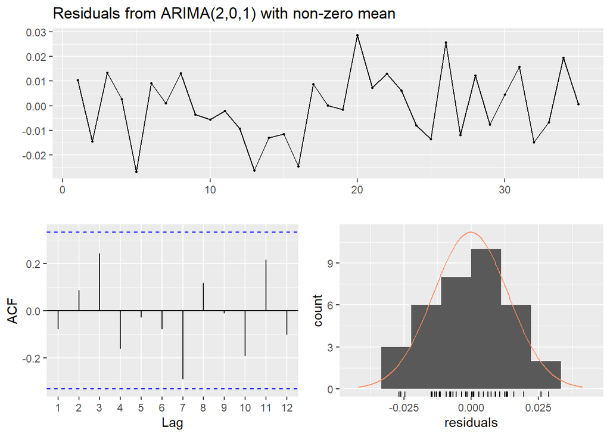

```
##
##  Ljung-Box test
##
## data:  Residuals from ARIMA(2,0,1) with non-zero mean
## Q* = 8.2488, df = 3, p-value = 0.04114
##
## Model df: 4.   Total lags used: 7
```

```r
checkresiduals(fit1)
```

Previsione

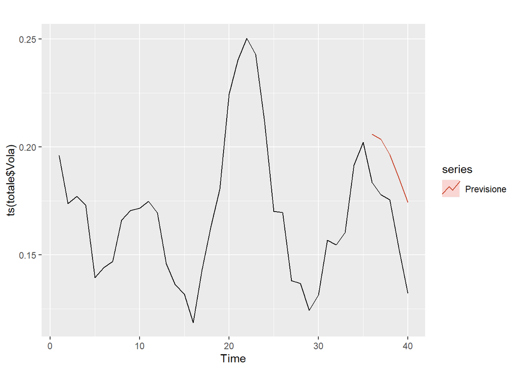

```r
prediction1 <- forecast(fit1,5)
autoplot(ts(totale$Vola)) +
  autolayer(prediction1 , series="Previsione",PI=FALSE)
```

Accuracy su test

```r
accuracy(prediction1, test$Vola)
```

```
##                         ME       RMSE        MAE         MPE     MAPE      MASE
## Training set -0.0002355843 0.01370523 0.01126917  -0.8580675  7.01005 0.7744643
## Test set     -0.0286560227 0.02970051 0.02865602 -18.2672837 18.26728 1.9693605
##                     ACF1
## Training set -0.07911259
## Test set              NA
```

Aggiungo serie del sentiment laggate risultate significative

```r
regressori <- cbind(train$lagJoy)

fit2 <- Arima(train$Vola, order=c(2,0,1),xreg= regressori)
fit2
```

```
## Series: train$Vola
## Regression with ARIMA(2,0,1) errors
##
## Coefficients:
##          ar1      ar2      ma1  intercept    xreg
##       1.6991  -0.8725  -0.7594     0.1538  0.3566
## s.e.  0.0883   0.0735   0.1830     0.0160  0.3277
##
## sigma^2 estimated as 0.0002102:  log likelihood=97.22
## AIC=-182.45   AICc=-179.34   BIC=-173.29
```

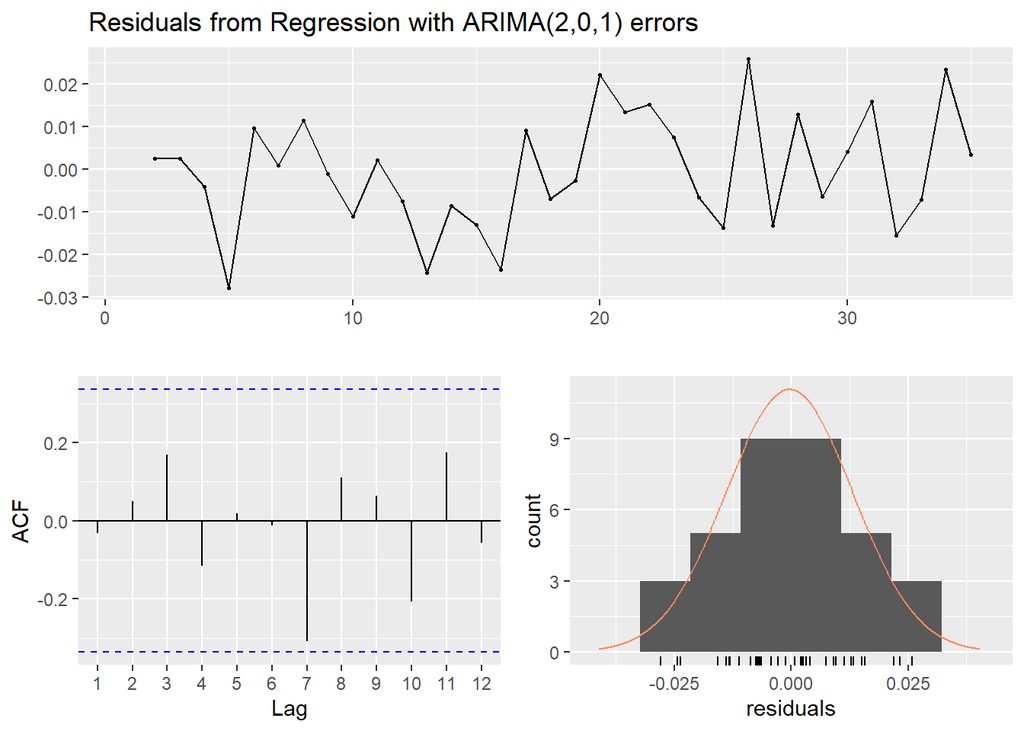

```
##
##  Ljung-Box test
##
## data:  Residuals from Regression with ARIMA(2,0,1) errors
## Q* = 6.7625, df = 3, p-value = 0.07987
##
## Model df: 5.   Total lags used: 8
```

```r
checkresiduals(fit2)
```

Previsione

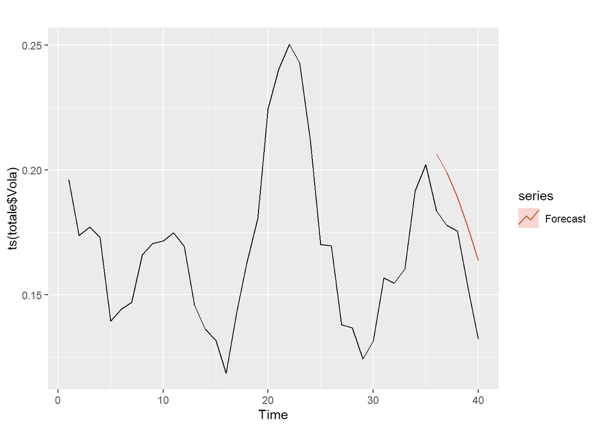

```r
regressoriTest <- cbind(test$lagJoy)

prediction2 <- forecast(fit2,5,xreg=regressoriTest)
autoplot(ts(totale$Vola)) +
  autolayer(prediction2 , series="Forecast",PI=FALSE)
```

Accuracy su test

```r
accuracy(prediction2, test$Vola)
```

```
##                         ME       RMSE        MAE        MPE      MAPE     MASE
## Training set -0.0003986876 0.01338982 0.01103356  -0.969889  6.870945 0.758272
## Test set     -0.0225452288 0.02326456 0.02254523 -14.254067 14.254067 1.549401
##                     ACF1
## Training set -0.03069066
## Test set              NA
```

Sentiment migliora la capacità previsiva del modello sulla volatilità.

Passo ora all’approccio senza dizionario tramite rete neurale Reti neurali:

Trasformo conteggio in TF-IDF

```r
tf_idf <-  tidy_tweets %>%
  count(date,word) %>%
  bind_tf_idf(word, date, n)
```

Parole più significative

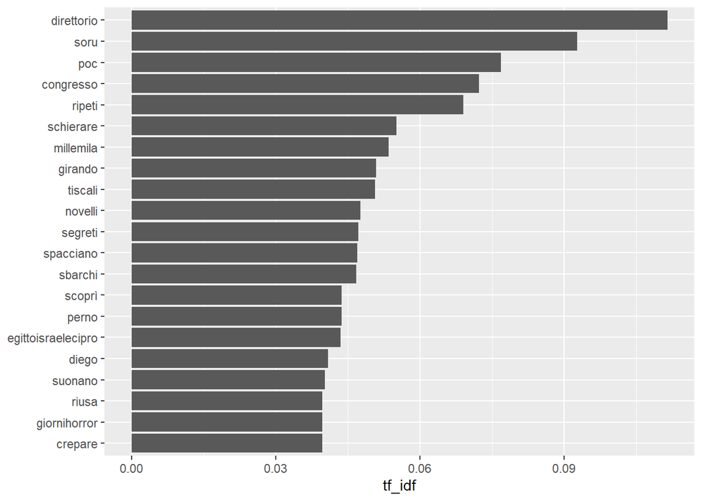

```r
tf_idf %>%
  top_n(20) %>%
  ggplot(aes(x = reorder(word, tf_idf), tf_idf)) +
  geom_col() +
  xlab(NULL) +
  coord_flip()
```

Formatto per algoritmo e rimuovo parole poco utilizzate

```r
tf_idf_dtm <- tf_idf %>%
             top_n(1500)  %>%
             cast_dtm(date, word, tf_idf)
tf_idf_ml <- as.matrix(tf_idf_dtm)
tf_idf_ml <- tf_idf_ml[5:44,]
```

```r
#unisco rendimenti spostati di un lag in avanti nel tempo
# cosi che i dati di oggi hanno come label l'andamento del giorno soccessivo
Indicetfidf <- Indice %>%
               filter(
                      date != as.Date("2020-09-04"),
                      )

traintemp <- cbind.data.frame(tf_idf_ml,na.omit(lead(Indicetfidf$vola)))
colnames(traintemp)[which(names(traintemp) == "na.omit(lead(Indicetfidf$vola))")] <- "Y"
traintemp <- traintemp %>%
  clean_names()
n <- names(traintemp)
f <- as.formula(paste("y ~", paste(n[!n %in% "y"], collapse = " + ")))
```

Train e Test

```r
trainRete <- traintemp[1:35,]
testRete <- traintemp[36:40,]
```

Rete Neurale

```r
nn <- neuralnet(f,data=trainRete,hidden=c(10,5,1),linear.output=T)
```

Valuto performance previsive su test

```r
predict <- compute(nn,testRete)
accuracy(ts(predict$net.result), testRete$y)
```

```
##                    ME      RMSE        MAE       MPE     MAPE
## Test set -0.002447362 0.0150591 0.01357904 -2.401616 8.687464
```

```r
predict$net.result
```

```
##                 [,1]
## 2020-09-28 0.1922196
## 2020-09-29 0.1601552
## 2020-09-30 0.1655710
## 2020-10-01 0.1607950
## 2020-10-02 0.1565594
```

Performance migliori del modello arma + sentiment ma migliori del modello solo arma

```r
predict <- compute(nn,testRete)
accuracy(ts(predict$net.result), testRete$y)
```

```
##                    ME      RMSE        MAE       MPE     MAPE
## Test set -0.002447362 0.0150591 0.01357904 -2.401616 8.687464
```

```r
predict$net.result
```

```
##                 [,1]
## 2020-09-28 0.1922196
## 2020-09-29 0.1601552
## 2020-09-30 0.1655710
## 2020-10-01 0.1607950
## 2020-10-02 0.1565594
```

Feature Importance

```r
featureimportance <- olden(nn)
```

Approccio ibrido, utilizzo pesi della rete per pesare ulteriolmente paralo nel vocabolario della sentiment.

Unisco risultato della rete con sentiment basata su dizionario

```r
importance <- as.data.frame (featureimportance$data)
importance$importance <- scale(importance$importance)
colnames(importance) <- c("importance","word")
```

Approccio differenze tra polarità :

```r
tidy_sentimentNew <-  tidy_tweets %>%
  inner_join(importance)
```

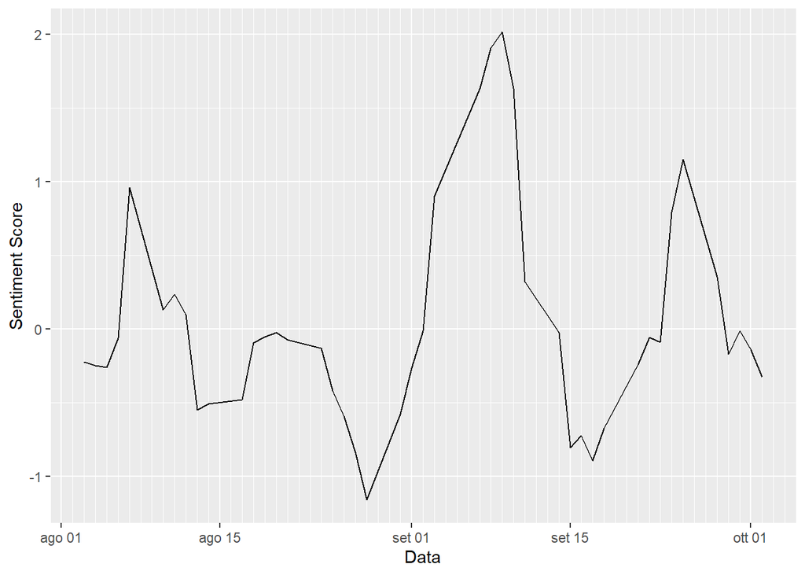

```r
Sentiment_ScoreNew <- tidy_sentimentNew  %>%
  group_by(date)%>%
  summarise(DailyScore = sum(importance)/n())

ggplot(Sentiment_ScoreNew, aes(x = date,y=DailyScore)) +
  geom_line() +
  labs(y = "Sentiment Score",x="Data")+
  scale_x_date(date_minor_breaks = "1 day")
```

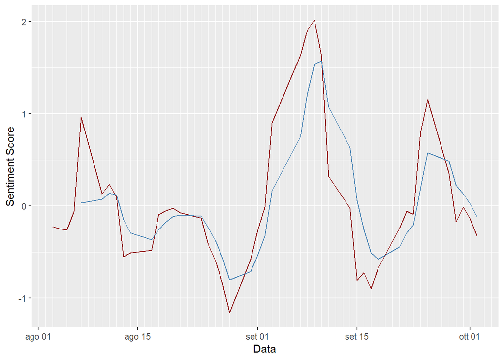

```r
smooth <- EMA(Sentiment_ScoreNew$DailyScore,n=5,ratio=0.4)
Sentiment_ScoreNew$Smooth <- smooth
ggplot(Sentiment_ScoreNew, aes(x = date)) +
  geom_line(aes(y = DailyScore), color = "darkred") +
  geom_line(aes(y = Smooth), color="steelblue") +
  labs(y = "Sentiment Score",x="Data")+
  scale_x_date(date_minor_breaks = "1 day")
```

Unisco dati relativi allo score all’indice

```r
# Indice$ScaleIndice <- scale(Indice$returns)
df_ScoreNew <-  Indice %>%
  inner_join(Sentiment_ScoreNew) %>%
  select(date,vola,Smooth)
colnames(df_ScoreNew) <- c("date","Indice","Sentiment")
df_ScoreNew <- df_ScoreNew[!is.na(df_ScoreNew$Indice), ]
df_ScoreNew
```

```
## # A tibble: 40 x 3
##    date       Indice Sentiment
##    <date>      <dbl>     <dbl>
##  1 2020-08-07  0.196    0.0336
##  2 2020-08-10  0.174    0.0716
##  3 2020-08-11  0.177    0.137
##  4 2020-08-12  0.173    0.120
##  5 2020-08-13  0.139   -0.147
##  6 2020-08-14  0.144   -0.292
##  7 2020-08-17  0.147   -0.366
##  8 2020-08-18  0.166   -0.257
##  9 2020-08-19  0.171   -0.176
## 10 2020-08-20  0.172   -0.115
## # ... with 30 more rows
```

Granger Test

```r
datalist = list()

for (i in 1:5) {
    dat <- grangertest(Indice ~ Sentiment, order = i, data = df_ScoreNew )
    dat$lag <- i
    datalist[[i]] <- dat
}

resultsSentiment1 = na.omit(do.call(rbind, datalist))
resultsSentiment1
```

```
## Granger causality test
##
## Model 1: Indice ~ Lags(Indice, 1:1) + Lags(Sentiment, 1:1)
## Model 2: Indice ~ Lags(Indice, 1:1)
##    Res.Df Df       F  Pr(>F) lag
## 2      37 -1 16.6122 0.00024   1
## 21     35 -2  3.0980 0.05848   2
## 22     33 -3  1.9677 0.14008   3
## 23     31 -4  0.6482 0.63299   4
## 24     29 -5  0.5735 0.71959   5
```

Inserisco nuovo sentiment in modello econometrico

train test

```r
totale2 <- df_ScoreNew %>% select(date,Sentiment,Indice)
colnames(totale2) <- c("date","Sentiment","Vola")
totale2 <- totale2 %>%
  mutate(lagSentiment =lag(Sentiment))


#Separo gli ultimi 3 giorni per stima out of sample
train2 <- totale2 %>% slice(1:35)
test2 <- totale2 %>% slice(36:40)
```

```r
regressori <- cbind(train2$lagSentiment,train$lagJoy)

fit3 <- Arima(train2$Vola, order=c(2,0,1),xreg= regressori)
fit3
```

```
## Series: train2$Vola
## Regression with ARIMA(2,0,1) errors
##
## Coefficients:
##          ar1      ar2      ma1  intercept   xreg1   xreg2
##       1.6421  -0.8422  -1.0000     0.1417  0.0194  0.5887
## s.e.  0.1003   0.0836   0.0867     0.0162  0.0082  0.3283
##
## sigma^2 estimated as 0.0001898:  log likelihood=98.55
## AIC=-183.1   AICc=-178.79   BIC=-172.41
```

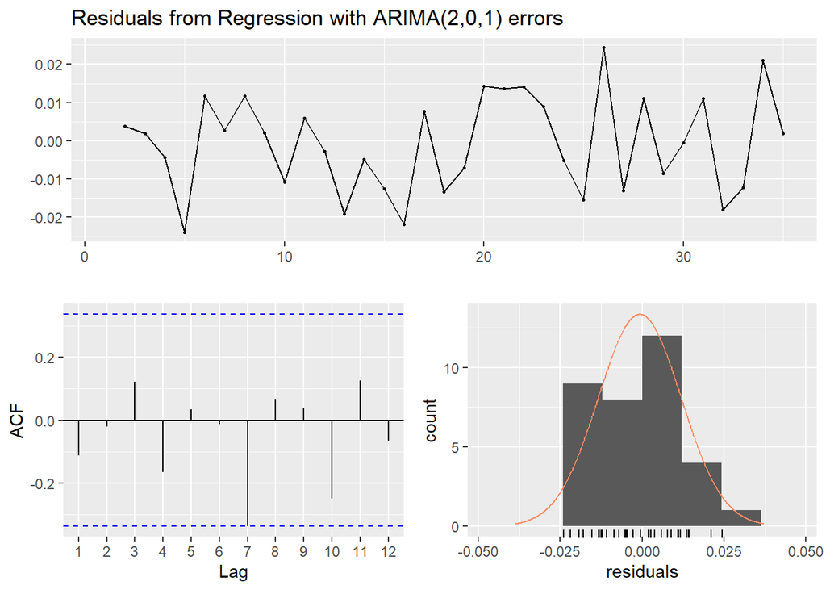

```
##
##  Ljung-Box test
##
## data:  Residuals from Regression with ARIMA(2,0,1) errors
## Q* = 7.6556, df = 3, p-value = 0.05369
##
## Model df: 6.   Total lags used: 9
```

```r
checkresiduals(fit3)
```

Previsione

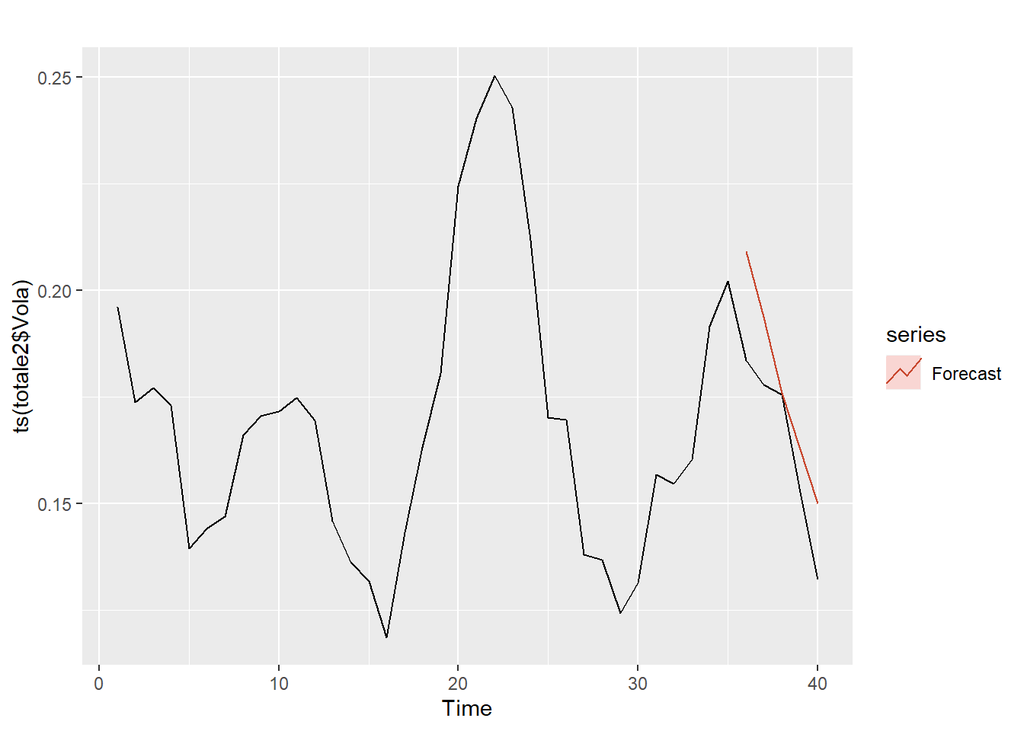

```r
regressoriTest2 <- cbind(test2$lagSentiment,test$lagJoy)

prediction3 <- forecast(fit3,5,xreg=regressoriTest2)
autoplot(ts(totale2$Vola)) +
  autolayer(prediction3 , series="Forecast",PI=FALSE)
```

Accuracy su test

```r
accuracy(prediction3, test2$Vola)
```

```
##                         ME       RMSE        MAE       MPE     MAPE      MASE
## Training set -0.0007554285 0.01250250 0.01063965 -1.142318 6.616124 0.7312005
## Test set     -0.0138449366 0.01623109 0.01384494 -8.556207 8.556207 0.9514813
##                    ACF1
## Training set -0.1126098
## Test set             NA
```